# 선형판별분석(Linear discriminant analysis)

Author

Yoon-Ho Hong

Published

September 3, 2023

## 선형판별분석(Linear discrminant analysis, LDA)

로지스틱 회귀는 로지스틱 함수를 이용하여 범주가 두 개인 결과변수에 대해 $Pr(Y=k|X=x)$를 직접 모델링하는 것입니다.

이제 선형판별분석(LDA)라고 불리는 대안 기법에 대해 알아봅시다.

LDA에서는 결과변수 Y의 각 클래스내의 관측치들이 클래스 별로 평균($\mu_k$)과 클래스 공통 분산($\sigma^2$)을 갖는 정규분포를 따른다고 가정합니다. 그리고, 파라미터에 대한 추정값을 베이즈 분류기를 이용해 구합니다.

베이즈 분류기(Bayes classifier)는 설명변수 X가 $x$로 주어졌을 때 반응변수 Y가 $k$ 클래스일 확률을 베이즈 정리를 이용해 구하는 것입니다.

베이즈 정리를 베이즈 분류기에 적용하면 아래 식이 된다.
$$P(Y=k|X=x) = \frac{P(X=x|Y=k) \times P(Y=k)}{\sum_{l=1}^k P(X=x|Y=l)}$$

위 베이즈 정리가 의미하는 것은 $P(Y=k|X=x)$(사후 확률)를 구하기 위해 사전 확률 $P(Y=k)$와 조건부 확률밀도 함수 $P(X=x|Y=k)$를 이용하는 것입니다.

$P(Y=k)$ 추정치는 k번째 클래스에 속하는 관측치들의 비율입니다.

$P(X=x|Y=k)$을 구하기 위해 LDA는 아래와 같은 가정을 합니다.

1. $P(X=x|Y=k)$은 정규 분포를 따른다.
2. 공통 분산을 갖는다(common variance across different k class)

우리는 위 가정과 k 클래스에 속한 관측치 데이터로부터 확률밀도함수 $P(X=x|Y=k)$와 $P(Y=k)$를 추정할 수 있습니다.

이들을 위 베이즈 정리에 대입하면 아래와 같은 선형판별함수를 얻을 수 있습니다.

$$\hat{\delta_k} = x\times\frac{\hat{\mu_k}}{\hat{\sigma}^2}-\frac{\hat{\mu_k}^2}{2\hat{\sigma}^2}+log(\hat{\pi_k})$$

$$\hat{\mu_k} = \frac{1}{n_k}\sum_{i:y_i=k}^{n}x_i$$

$$\hat{\sigma^2} = \frac{1}{n-K}\sum_{k=1}^{K}\sum_{i:y_i=k}(x_i-\hat{\mu_k})^2$$
$$\hat{\pi_k}=\frac{n_k}{n}$$

LDA 분류기는 위식에서 $\hat{\delta_k}$ 값이 최대가 되는 클래스 k에 관측치($X=x$)를 할당합니다.

위 식을 선형판별함수(linear disciminant function)이라고 하는 것은 위 판별함수가 x의 선형함수이기 때문입니다.

## 선형판별함수에 대한 이해: 기하학적 접근법

**figure**

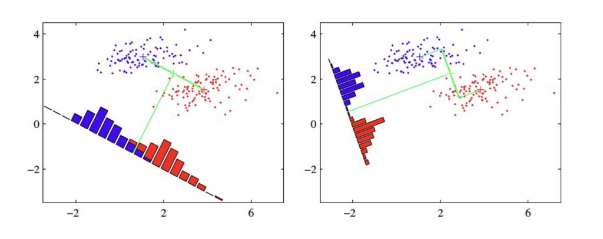

LDA는 나중에 살펴볼 PCA (principal component analysis)와 매우 유사하다. 어떤 유사점과 차이점이 있는지 알아보자.

[LDA & PCA](https://www.youtube.com/watch?v=azXCzI57Yfc)

## 로지스틱 회귀 vs. LDA: 장단점 비교

로지스틱 회귀와 비교하여 LDA의 장점은 다음과 같습니다.

클래스의 수가 2보다 많은 반응 변수를 분류해야 할 때가 있습니다. 다중 로지스틱회귀 모델이 있지만 실제로는 자주 사용되지 않습니다.

클래스들이 잘 분리될 때 로지스틱 회귀모델에 대한 모수 추정치는 불안정한 경향이 있습니다. 선형판별분석은 이런 문제가 없습니다.

만약 n이 작고, 각 클래스에서 설명변수 X의 분포가 근사적으로 정규분포이면 선형판별모델이 로지스틱회귀모델보다 더 안정적입니다.

## LDA 실습

titanic 예제에서 LDA 실습을 해봅시다.

```r
library(carData)
TitanicSurvival = TitanicSurvival[complete.cases(TitanicSurvival),]
set.seed(1)
cnt = dim(TitanicSurvival)[1]
index = sample(cnt, round(cnt/7), replace = F)
train.data = TitanicSurvival[-index,]
test.data = TitanicSurvival[index,]
```

lda 함수를 위해 필요한 패키지를 로딩하고 lda 함수로 training 데이터에 모델을 적합합니다.

```r
library(MASS)
lda.fit = lda(survived~., data = train.data)
```

LDA fit 결과를 살펴봅시다.

```r
lda.fit
```

```
Call:
lda(survived ~ ., data = train.data)

Prior probabilities of groups:
       no       yes
0.5841695 0.4158305

Group means:
      sexmale      age passengerClass2nd passengerClass3rd
no  0.8492366 30.56266         0.2270992         0.5992366
yes 0.3109920 28.76072         0.2520107         0.3163539

Coefficients of linear discriminants:
                          LD1
sexmale           -2.10339109
age               -0.02247706
passengerClass2nd -0.84560588
passengerClass3rd -1.52529521
```

Group mean 은 집단별(사망 vs. 생존) 예측변수(sex, age, passengerClass)의 평균을 의미합니다.

Coefficients of linear discriminants는 LDA분석으로 계산된 판별함수식의 계수가 되겠습니다. 생존 여부를 분류하는, 즉 2개의 범주를 분류하는 것이므로 1개의 판별함수식(LD1)이 만들어짐을 확인할 수 있습니다.

각 클래스에서 LD 값의 분포를 알고 싶다면…

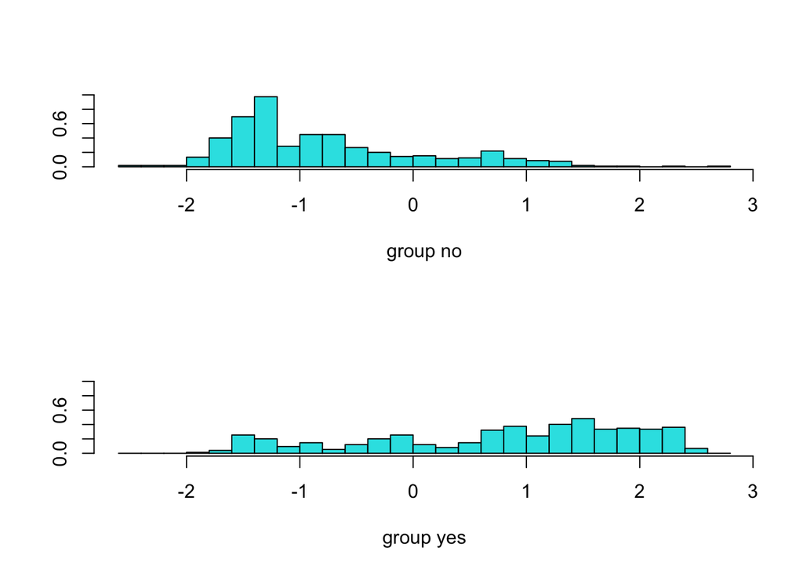

```r
plot(lda.fit)
```

위에서 만든 LDA 모델을 이용해 test data에서 생존 결과를 예측해봅시다.

```r
pred = predict(lda.fit, test.data)
class(pred)
```

```
[1] "list"
```

```r
names(pred)
```

```
[1] "class"     "posterior" "x"
```

class는 예측 결과값을, posterior는 각 클래스일 확률을, x는 linear discriminant function 값을 반환합니다.

```r
head(pred$class)
```

```
[1] no  no  yes no  no  yes
Levels: no yes
```

```r
head(pred$posterior)
```

```
                                        no        yes
Vande Velde, Mr. Johannes Josep 0.94507895 0.05492105
Cribb, Mr. John Hatfield        0.96219510 0.03780490
Harder, Mrs. George Achilles (D 0.03978374 0.96021626
Persson, Mr. Ernst Ulrik        0.92828989 0.07171011
Norman, Mr. Robert Douglas      0.83082332 0.16917668
Beane, Mrs. Edward (Ethel Clark 0.11319094 0.88680906
```

실제 관측치와 예측치가 얼마나 일치하는지 알아보기 위해 confusion matrix 를 구해봅시다.

```r
table(pred$class, test.data$survived)
```

```
      no yes
  no  78  17
  yes 17  37
```

예측 정확도는? 로지스틱회귀모델과 비교하여 분류 정확도는?

```r
mean(pred$class == test.data$survived)
```

```
[1] 0.7718121
```